# Lab 7

2026-01-27

## Learning Goals

*At the end of this exercise, you will be able to:*  
1. Produce statistical summaries using `summarize()`.  
4. Produce counts using `count()`.

## Load the libraries

```r
library("tidyverse")
library("janitor")
```

## Data

For this lab, we will use the built-in data on mammal sleep patterns, `msleep`. From: *V. M. Savage and G. B. West. A quantitative, theoretical framework for understanding mammalian sleep. Proceedings of the National Academy of Sciences, 104 (3):1051-1056, 2007*.

```r
msleep
```

```
## # A tibble: 83 × 11
##    name   genus vore  order conservation sleep_total sleep_rem sleep_cycle awake
##    <chr>  <chr> <chr> <chr> <chr>              <dbl>     <dbl>       <dbl> <dbl>
##  1 Cheet… Acin… carni Carn… lc                  12.1      NA        NA      11.9
##  2 Owl m… Aotus omni  Prim… <NA>                17         1.8      NA       7
##  3 Mount… Aplo… herbi Rode… nt                  14.4       2.4      NA       9.6
##  4 Great… Blar… omni  Sori… lc                  14.9       2.3       0.133   9.1
##  5 Cow    Bos   herbi Arti… domesticated         4         0.7       0.667  20
##  6 Three… Brad… herbi Pilo… <NA>                14.4       2.2       0.767   9.6
##  7 North… Call… carni Carn… vu                   8.7       1.4       0.383  15.3
##  8 Vespe… Calo… <NA>  Rode… <NA>                 7        NA        NA      17
##  9 Dog    Canis carni Carn… domesticated        10.1       2.9       0.333  13.9
## 10 Roe d… Capr… herbi Arti… lc                   3        NA        NA      21
## # ℹ 73 more rows
## # ℹ 2 more variables: brainwt <dbl>, bodywt <dbl>
```

## Summary statistics

When first exploring data, it is often a good idea to produce some basic summary statistics. This can help you identify potential problems with the data (e.g., outliers, missing values, skew) as well as get a general sense of the distribution of values for a given variable. So far, you have learned to calculate summary statistics using *base R* functions such as `mean()`, `sd()`, `min()`, and `max()`.

## Practice

1. Calculate the mean body weight of large and small mammals in msleep. Large mammals have a body weight greater than 150, while small mammals have a body weight less than 10. I did large mammals for you as an example.

```r
large <- msleep %>%
  filter(bodywt > 150) %>%
  arrange(desc(bodywt))
large
```

```
## # A tibble: 11 × 11
##    name   genus vore  order conservation sleep_total sleep_rem sleep_cycle awake
##    <chr>  <chr> <chr> <chr> <chr>              <dbl>     <dbl>       <dbl> <dbl>
##  1 Afric… Loxo… herbi Prob… vu                   3.3      NA        NA      20.7
##  2 Asian… Elep… herbi Prob… en                   3.9      NA        NA      20.1
##  3 Giraf… Gira… herbi Arti… cd                   1.9       0.4      NA      22.1
##  4 Pilot… Glob… carni Ceta… cd                   2.7       0.1      NA      21.4
##  5 Cow    Bos   herbi Arti… domesticated         4         0.7       0.667  20
##  6 Horse  Equus herbi Peri… domesticated         2.9       0.6       1      21.1
##  7 Brazi… Tapi… herbi Peri… vu                   4.4       1         0.9    19.6
##  8 Donkey Equus herbi Peri… domesticated         3.1       0.4      NA      20.9
##  9 Bottl… Turs… carni Ceta… <NA>                 5.2      NA        NA      18.8
## 10 Tiger  Pant… carni Carn… en                  15.8      NA        NA       8.2
## 11 Lion   Pant… carni Carn… vu                  13.5      NA        NA      10.5
## # ℹ 2 more variables: brainwt <dbl>, bodywt <dbl>
```

```r
small <- msleep
```

```r
small <- msleep %>%
  filter(bodywt < 10) %>%
  arrange(desc(bodywt))
small
```

```
## # A tibble: 56 × 11
##    name   genus vore  order conservation sleep_total sleep_rem sleep_cycle awake
##    <chr>  <chr> <chr> <chr> <chr>              <dbl>     <dbl>       <dbl> <dbl>
##  1 Macaq… Maca… omni  Prim… <NA>                10.1       1.2       0.75   13.9
##  2 Grivet Cerc… omni  Prim… lc                  10         0.7      NA      14
##  3 Short… Tach… inse… Mono… <NA>                 8.6      NA        NA      15.4
##  4 Red f… Vulp… carni Carn… <NA>                 9.8       2.4       0.35   14.2
##  5 Three… Brad… herbi Pilo… <NA>                14.4       2.2       0.767   9.6
##  6 Rock … Proc… <NA>  Hyra… lc                   5.4       0.5      NA      18.6
##  7 Long-… Dasy… carni Cing… lc                  17.4       3.1       0.383   6.6
##  8 Arcti… Vulp… carni Carn… <NA>                12.5      NA        NA      11.5
##  9 Domes… Felis carni Carn… domesticated        12.5       3.2       0.417  11.5
## 10 Tree … Dend… herbi Hyra… lc                   5.3       0.5      NA      18.7
## # ℹ 46 more rows
## # ℹ 2 more variables: brainwt <dbl>, bodywt <dbl>
```

```r
mean(large$bodywt)
```

```
## [1] 1173.99
```

```r
mean(small$bodywt)
```

```
## [1] 1.201304
```

## `summarize()`

Fortunately, dplyr has some functions that make producing summary statistics easier. The verb `summarize()` produces summary statistics for a given variable in a data frame. Let’s try the examples above using `summarize()`.

Large mammals

```r
msleep %>%
  filter(bodywt>150) %>%
  summarize(mean_bodywt_lg=mean(bodywt))
```

```
## # A tibble: 1 × 1
##   mean_bodywt_lg
##            <dbl>
## 1          1174.
```

Small mammals

```r
msleep %>%
  filter(bodywt<10) %>%
  summarize(mean_bodywt_sm=mean(bodywt)) #summarize used to get quick stats summary
```

```
## # A tibble: 1 × 1
##   mean_bodywt_sm
##            <dbl>
## 1           1.20
```

You can also combine functions to make summaries for multiple variables.

```r
msleep %>%
  filter(bodywt>150) %>%
  summarize(mean_bodywt_lg=mean(bodywt), min_bodywt_lg=min(bodywt),
max_bodywt_lg=max(bodywt), sd_bodywt_lg=sd(bodywt), total=n())
```

```
## # A tibble: 1 × 5
##   mean_bodywt_lg min_bodywt_lg max_bodywt_lg sd_bodywt_lg total
##            <dbl>         <dbl>         <dbl>        <dbl> <int>
## 1          1174.          161.          6654        1945.    11
```

Maybe you want to summarize all of the numeric variables in the data frame. You can use the `where()` function to select only the numeric variables.

```r
msleep %>%
  select(where(is.numeric)) %>%
  summarise_all(mean) #but gives NAs if. you leave it here
```

```
## # A tibble: 1 × 6
##   sleep_total sleep_rem sleep_cycle awake brainwt bodywt
##         <dbl>     <dbl>       <dbl> <dbl>   <dbl>  <dbl>
## 1        10.4        NA          NA  13.6      NA   166.
```

Don’t forget to remove NA’s.

```r
msleep %>%
  select(where(is.numeric)) %>%
  summarise_all(mean, na.rm=T)
```

```
## # A tibble: 1 × 6
##   sleep_total sleep_rem sleep_cycle awake brainwt bodywt
##         <dbl>     <dbl>       <dbl> <dbl>   <dbl>  <dbl>
## 1        10.4      1.88       0.440  13.6   0.282   166.
```

This is a little more efficient.

```r
msleep %>%
  summarize(across(where(is.numeric),
                   ~mean(.x, na.rm=T))) #.x means all observations, all are not NA
```

```
## # A tibble: 1 × 6
##   sleep_total sleep_rem sleep_cycle awake brainwt bodywt
##         <dbl>     <dbl>       <dbl> <dbl>   <dbl>  <dbl>
## 1        10.4      1.88       0.440  13.6   0.282   166.
```

## Practice

1. What is the mean, min, and max `bodywt` for the taxonomic order Primates? Provide the total number of observations.

```r
msleep %>%
  filter(order=="Primates") %>%
  summarize(mean_bodywt_primate=mean(bodywt),
            min_bodywt_primate=min(bodywt),
            max_bodywt_primate=max(bodywt),
            total=n())
```

```
## # A tibble: 1 × 4
##   mean_bodywt_primate min_bodywt_primate max_bodywt_primate total
##                 <dbl>              <dbl>              <dbl> <int>
## 1                13.9                0.2                 62    12
```

`n_distinct()` is a handy way of cleanly presenting the number of distinct observations. Notice that there are 9 genera with over 100 in body weight.

Here we show the number of distinct genera over 100 in body weight.

```r
msleep %>%
  filter(bodywt>100) %>%
  summarize(n_genera=n_distinct(genus))
```

```
## # A tibble: 1 × 1
##   n_genera
##      <int>
## 1        9
```

```r
msleep %>%
  filter(bodywt>100) %>%
  n_distinct() #this give you 11 bc in table there are repeats of genus
```

```
## [1] 11
```

Not to be confused with n(), which counts the total number of observations.

```r
msleep %>%
  filter(bodywt>100) %>%
  summarize(total=n()) #also shows repeats
```

```
## # A tibble: 1 × 1
##   total
##   <int>
## 1    11
```

`pull()` is another useful verb that extracts a single column from a data frame as a vector.

```r
msleep %>%
  filter(bodywt>100) %>%
  distinct() %>% #if you add genus inside distinct then it will not give repeats of genus
  pull(genus)
```

```
##  [1] "Bos"           "Elephas"       "Equus"         "Equus"
##  [5] "Giraffa"       "Globicephalus" "Loxodonta"     "Panthera"
##  [9] "Panthera"      "Tapirus"       "Tursiops"
```

## Practice

1. How many genera are represented in the msleep data frame?

```r
msleep %>%
  summarize(n_genera=n_distinct(genus))
```

```
## # A tibble: 1 × 1
##   n_genera
##      <int>
## 1       77
```

## Counts

Although `summarize()` is helpful, oftentimes we are only interested in counts. The [janitor package](https://garthtarr.github.io/meatR/janitor.html) does a lot with counts, but there are also functions that are part of dplyr that are useful.

For example, if we wanted to count the number of observations for each `vore` category in the `msleep` data frame we could do the following:

```r
msleep %>%
  count(vore, sort=T) #sort in descending order
```

```
## # A tibble: 5 × 2
##   vore        n
##   <chr>   <int>
## 1 herbi      32
## 2 omni       20
## 3 carni      19
## 4 <NA>        7
## 5 insecti     5
```

vore = x, n = y axis; you can make a plot

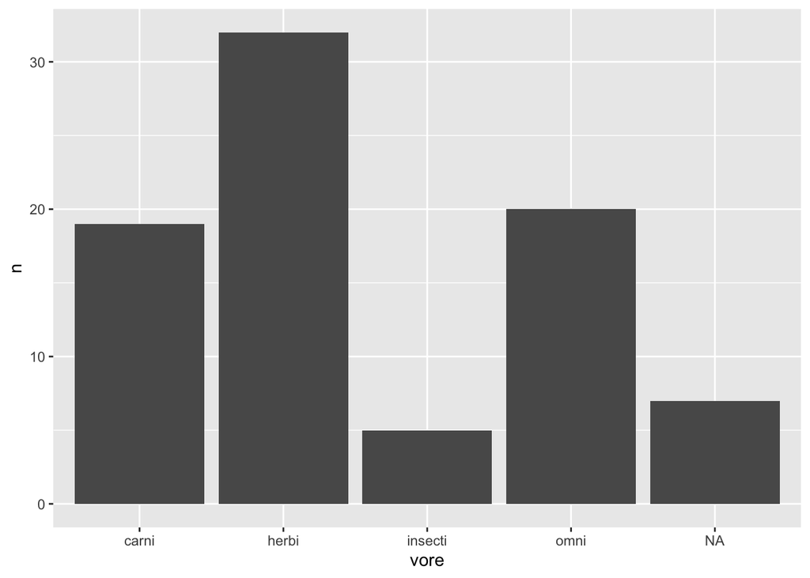

```r
msleep %>%
  count(vore) %>%
  ggplot(aes(x=vore, y=n))+
  geom_col()
```

You can even combine multiple variables to get counts. For example, if we wanted to count the number of observations for each `vore` category within each `order` category we could do the following:

```r
msleep %>%
  count(vore, order)
```

```
## # A tibble: 32 × 3
##    vore  order               n
##    <chr> <chr>           <int>
##  1 carni Carnivora          12
##  2 carni Cetacea             3
##  3 carni Cingulata           1
##  4 carni Didelphimorphia     1
##  5 carni Primates            1
##  6 carni Rodentia            1
##  7 herbi Artiodactyla        5
##  8 herbi Diprotodontia       1
##  9 herbi Hyracoidea          2
## 10 herbi Lagomorpha          1
## # ℹ 22 more rows
```

The tabyl() function from the janitor package is also very useful for producing counts and percentages.

```r
msleep %>%
  tabyl(vore)
```

```
##     vore  n    percent valid_percent
##    carni 19 0.22891566    0.25000000
##    herbi 32 0.38554217    0.42105263
##  insecti  5 0.06024096    0.06578947
##     omni 20 0.24096386    0.26315789
##     <NA>  7 0.08433735            NA
```

## Practice

1. In the taxonomic order Carnivora, count the number of observations for each conservation status.

```r
msleep %>%
  filter(order=="Carnivora") %>%
  count(conservation)
```

```
## # A tibble: 6 × 2
##   conservation     n
##   <chr>        <int>
## 1 domesticated     2
## 2 en               1
## 3 lc               2
## 4 nt               1
## 5 vu               3
## 6 <NA>             3
```

2. Among herbivores, which order is most represented? Return the top 5 orders with counts, sorted in descending order.

```r
msleep %>%
  filter(vore=="herbi") %>%
  count(vore,order, sort=T)
```

```
## # A tibble: 9 × 3
##   vore  order              n
##   <chr> <chr>          <int>
## 1 herbi Rodentia          16
## 2 herbi Artiodactyla       5
## 3 herbi Perissodactyla     3
## 4 herbi Hyracoidea         2
## 5 herbi Proboscidea        2
## 6 herbi Diprotodontia      1
## 7 herbi Lagomorpha         1
## 8 herbi Pilosa             1
## 9 herbi Primates           1
```

–>[Home](https://jmledford3115.github.io/datascibiol/)